# act_report

## Report: act_report

This project which is known as wrangle and analyze data involves the wrangling of WeRateDogs twitter archive data from the period of 2015 to 2017. The twitter archive data was made available to Udacity by the twitter user was used for the purpose of this project’s objective. See archive [here](https://d17h27t6h515a5.cloudfront.net/topher/2017/August/59a4e958_twitter-archive-enhanced/twitter-archive-enhanced.csv).

The goal of this project is to wrangle WeRateDogs twitter data to create interesting and trustworthy analyses and visualizations. The twitter data however contains very basic information. Therefore, gathering of additional data was carried out using twitter API and image prediction data was also collected [here](https://d17h27t6h515a5.cloudfront.net/topher/2017/August/599fd2ad_image-predictions/image-predictions.tsv) prior to cleaning and assessing of the data.

Following the cleaning, assessment, and analysis of all the data collected from the different sources, some insights were garnered, and appropriate visualizations produced to showcase these insights. The following questions formed the basis our analysis:

- How many tweet images corresponds to a breed of dog, and how many were not dog images?
- What is the proportion of dog ratings across the different dog images reviewed?
- Which day of the year and month within the period had the highest amount of likes and retweets.

In answering the first question, we gathered that out of a total of 1994 rows of dog image prediction data analyzed, only 1477 were images of dog breeds while 517 were not even dog breeds. Meaning that of all images posted within the period of November 2015 to August 2017, only 74% of all images posted for ratings on WeRateDogs twitter page were actual pictures of dogs while 26% were not even pictures of dogs.

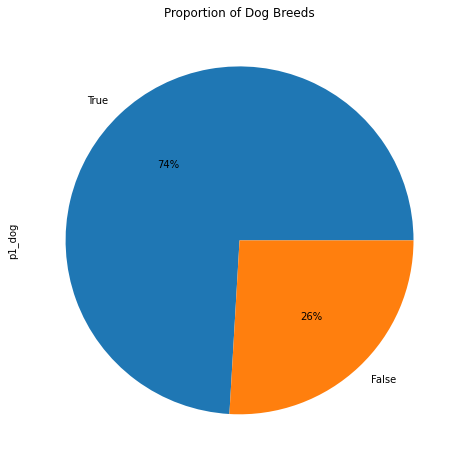

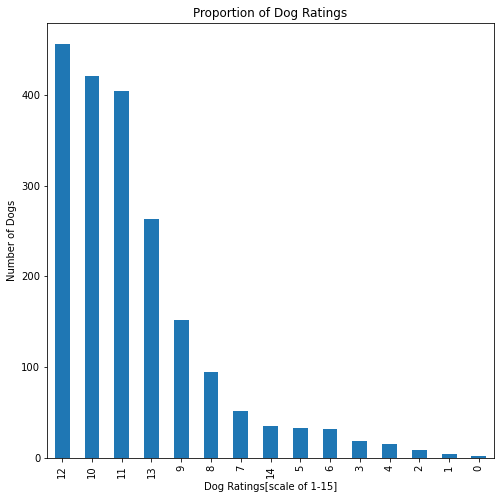

Lastly, we were also able to gather from our analysis that within the period in question - *November 2015 - August 2017*, the tweet with the highest retweet count and favorite count(likes) was tweeted on the 18th of June 2016 at 7.26pm from an iPhone with a test “**Here's a doggo realizing you can stand in a pool. 13/10 enlightened af (vid by Tina Conrad)**” and tweet [URL](https://twitter.com/dog_rates/status/744234799360020481/) with 70,331 retweets and 144,247 likes on that particular tweet.